# Replication of Study Attention Alters Perceived Attractiveness (Experiment 3) by Störmer & Alvarez (2016, Psychological Science)

Minyoung Lee (minyoung.lee@stanford.edu)

March 21, 2017

## Introduction

In their study, Störmer & Alvarez (2016) tested whether attention can alter the appearance of real-world stimuli. They asked three questions: **1)** Does attention alter perceived attractiveness of faces? **2)** Is the change in attractiveness judgments driven by exogenous (involuntary) attention? **3)** Does the attentional cue influence attractive judgments by modulating the apparent local contrast of the faces? Their results showed that attention altered the perception of facial attractiveness which belongs to higher-level aspects of perception. **In the current replication project, we aim to replicate Experiment 3 of the original study in which the authors found that attention increased the apparent contrast around the eye region of faces which has been reported to modulate facial attractiveness.**

## Methods

### Power Analysis

The effect size for the key statistical test (the paired-samples *t* test) reported in the original paper was $\eta^2=0.30$. We computed *Cohen’s d<sub>z</sub>* based on statistics provided in the paper (55.8% vs. 45.8%, $t$(15) = 2.51, $p$ = .02, $\eta^2$=0.30).

```r
N <- 16
meanDiff <- 55.8 - 45.8
t <- 2.51  # t = meanDiff / se_of_meanDiff
se_d <- meanDiff/t
s_d <- se_d * sqrt(N) # standard deviation of the mean differences
d_z <- meanDiff / s_d
# also equals
d_z <- t/sqrt(N)
```

Based on the computed effect size of *d<sub>z</sub>* = 0.6275, we performed post hoc power analysis using G*Power. The analysis indicated that the power of the original study was *0.65*. We would need a sample size of *N* = 22 to achieve 80% power, *N* = 29 to achieve 90% power, and *N* = 35 to achieve 95% power to be able to detect the reported effect size. We aim to acieve 80% power. However, to shorten the duration of the experiment for each participant, we are going to split the experiment into halves and double the number of participants. That will give us *N* = 44.

### Planned Sample

We plan to recruit 44 US participants on mTruk.

### Materials

[output not shown]

The experimental materials used in the original study (i.e., contrast manipulated face images) were provided by the original authors. Although we used the same stimuli, the size, brightness and spacing of stimuli could not be precisely controlled due to several constraints in the experimental settings as our experiment was conducted online on the Amazon Mechanical Turk (e.g., different displays, web browing environments, etc). However, we tried to keep the relative sizes and positions of stimuli as close to those in the original study as possible.

### Procedure

[output not shown]

The experimental procedures were followed precisely, except for the following changes:

- The presentation of stimuli was controlled by Java.
- As mentioned before, we did not have control over the size, resolution and refresh rate of displays. Also, the testing environments were considerably different from the original study – Turkers’ presumably worked from their home viewing the screen at a random distance without a chin rest and without an eye tracker recording their gaze positions.
- There were also a few differences in the duration of stimulus presentation. Considering that the most common refresh rates for computer screens include 30Hz and 60Hz, we fixed the lengths of cue and face presentation at 66 ms instead of 70 ms and 58 ms, respectively. Thus, the stimulus onset asynchrony (SOA) between the attentional cue and the faces in our version of the experiment was 132 ms which was 4 ms longer than in the original study. However, we did not expect that difference to be effective enough to abolish the attentional cueing effect.

### Analysis Plan

> There was a main effect of actual contrast level on contrast judgments, $F$(4, 15) = 27.93, $p$= .0001, $\eta^2$ = .31. Participants chose the face with higher contrast around the eye region more often than the face with lower contrast around the eye region. As in the previous experiments, our main analysis focused on the matched-face trials, in which identical faces were presented at Contrast Level 3. As shown in Figure 4b, when the two faces were physically identical, participants tended to judge the face at the cued location to have higher contrast than the face at the uncued location (55.8% vs.45.8%), $t$(15) = 2.51, $p$ = .02, $\eta^2$ = .30.

#### Key Analysis of Interest

1. We will conduct a repeated measures analysis of variance (ANOVA) to test for the overall effect of contrast regardless of attentional manipulation. This will test the effect of physical contrast on contrast judgments (i.e., the number of times a face is chosen as having higher contrast).
2. We will fit data (% choice) to a cumulative Weibull function using the maximum likelihood estimation (MLE), for “test face cued” and for “standard face cued” condition separately.
3. We will conduct a paired sample t-test to examine whether the attented face is judged to have higher contrast than the unattended face is when the physical contrast of the two faces is identical.

### Differences from Original Study

The original study was conducted in a highly controlled experimental setting typical for psychophysics experiments. There will be several differences from the original study. We will have less control over the display (e.g., size, luminance, resolution, refresh rate etc.), timing of stimulus presentation, testing environment and so on.

#### Differences from pre-data collection methods plan

## Results

### Data preparation

```r
###Data Preparation
path <- "~/class/StanfordPsych254/stormer/"
files <- dir(paste0(path,"mturk/sandbox-results/"),
             pattern = "*.json")
d.raw <- data.frame()

####Import data
for (f in files) {
  jf <- paste0(path, "mturk/sandbox-results/",f)
  jd <- jsonlite::fromJSON(paste(readLines(jf)), flatten=TRUE)
  stimCond <- jd$answers$data$stimCond
  resp <- jd$answers$data$data
  id <- data.frame(workerid = jd$WorkerId)
  id <- cbind(id,stimCond,resp)

  d.raw <- bind_rows(d.raw, id)
}
# Number of participants
length(unique(d.raw$workerid))
```

```
## [1] 1
```

#### Prepare data for analysis - create columns etc.

```r
# as factor
d.raw[sapply(d.raw, is.character)] <- lapply(d.raw[sapply(d.raw, is.character)], as.factor)
d.raw$face <- factor(d.raw$face)
d.raw$testContrast <- factor(d.raw$testContrast)

# retrieve the face chosen and the vertical position of target face in each trial
d<-d.raw %>%
  mutate(testVertical = factor(ifelse((testPos=="left"&leftUp==T)|(testPos=="right"&leftUp==F),"up",                           ifelse((testPos=="left"&leftUp==F)|(testPos=="right"&leftUp==T),"down",NA)))) %>%
  mutate(chosen = factor(ifelse(testVertical==keypress,"test","standard")))

head(d)
```

```
##        workerid  ITI face      cue   cueLoc leftUp testPos testContrast
## 1 A67ZF3232ZW0D 1122   20 standard  leftCue  FALSE   right            4
## 2 A67ZF3232ZW0D 1322    6     test rightCue   TRUE   right            5
## 3 A67ZF3232ZW0D 1276    3 standard rightCue  FALSE    left            4
## 4 A67ZF3232ZW0D 1094    9     test  leftCue   TRUE    left            2
## 5 A67ZF3232ZW0D 1363   11 standard  leftCue   TRUE   right            5
## 6 A67ZF3232ZW0D 1474   14     test  leftCue   TRUE    left            2
##    rt keypress testVertical   chosen
## 1 784       up           up     test
## 2 635     down         down     test
## 3 660     down         down     test
## 4 750     down           up standard
## 5 513     down         down     test
## 6 595     down           up standard
```

```r
# calculate the % of trials where participants answered that "test" face had higher contrast than "standard" face
tbl <- d %>%
  group_by(workerid,cue,testContrast) %>%
  summarise(n=n(),testChosen=sum(chosen=="test"),
            standardChosen=sum(chosen=="standard"),pctTest=testChosen/n*100)

# prep data for plotting
tbl <- tbl %>%
  group_by(workerid) %>%
  mutate(workerMean=mean(pctTest)) %>% # worker means across conditions
  ungroup() %>%
  mutate(grandMean=mean(workerMean)) %>% # grand mean across subjects
  # To compute within subject errors later
 # new value = old value – subject average + grand average
  mutate(newPct=pctTest-workerMean+grandMean)
```

### Confirmatory analysis

#### Manipulation check: ANOVA

```r
anova1 <- ezANOVA(data=tbl, dv=pctTest, wid=workerid,within=testContrast,within_full=cue,detailed=TRUE)
print(anova1$ANOVA)
```

```
##         Effect DFn DFd      SSn SSd   F   p p<.05 ges
## 1  (Intercept)   1   0 12375.31   0 NaN NaN    NA   1
## 2 testContrast   4   0  6882.50   0 NaN NaN    NA   1
```

#### Figure 4a. Psychometric functions

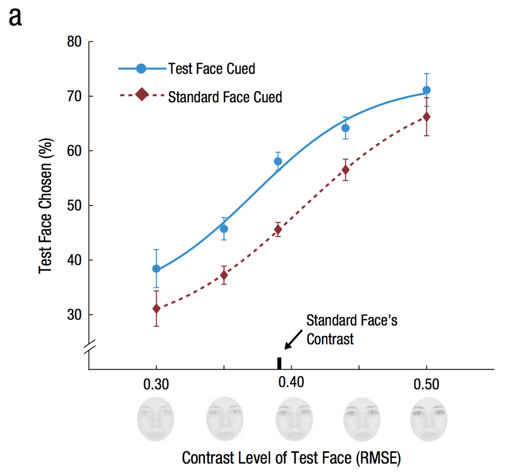

“The psychometric functions (a) show the percentage of all trials in which participants chose the test face as having higher contrast than the standard face as a function of the test face’s contrast. Error bars represent ±1 SEM (within subjects). *p<.05."

```r
# get mean psychometric
psychometric <- tbl %>%
  group_by(cue,testContrast) %>%
  # mean and within subject errors
  summarise(avePct=mean(pctTest), se=sd(newPct)/sqrt(n()),
            ntrial=mean(n),aveTestChosen=mean(testChosen),
            sumTest=sum(testChosen),sumN=sum(n))
psychometric <- psychometric %>%
  mutate(RMScontrast = c(.30,.35,.39,.44,.50))
# psychometric %>%
#   ggplot(aes(x=RMScontrast,y=avePct,group=cue,color=cue)) +
#   geom_point(size=3) +
#   ggthemes::theme_few()
#   # geom_pointrange(aes(ymin=avePct-se, ymax=avePct+se))
```

#### Psychometric curve fit using MLE

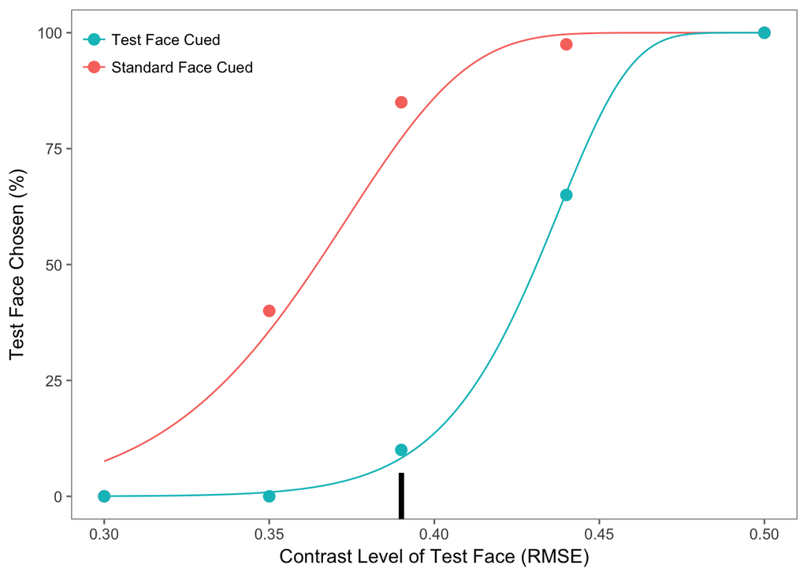

```r
RMScontrast = c(.30,.35,.39,.44,.50)
x<-RMScontrast
n<-psychometric$sumN #n trial per condition
k <- psychometric$sumTest # number of times that the observer reports that can see the stimulus
y <- k/n
cue <- psychometric$cue
dat <- data.frame(cue,x, k,n, y)
# define function for fitting binomial (MLE)
fitting <- function(df){
  nll <- function(p) {
  phi <- pweibull(df$x, p[1], p[2])
  -sum(df$k * log(phi) + (df$n - df$k) * log(1 - phi))
  }
para <- optim(c(.7,.7), nll)$par
xseq <- seq(.3,.5,.001)
yseq <- pweibull(xseq, para[1], para[2])
data.frame(xseq,yseq)
}
# plot
npoints <- 201
curves <- dat %>%
  split(.$cue) %>%
  map_df(fitting)
curves$cue <-rbind(matrix(rep("standard",npoints)), matrix(rep("test",npoints)))

p<- psychometric %>%
  ggplot(aes(x=RMScontrast,y=avePct,group=cue,color=cue)) +
  geom_point(size=3) +
  # geom_pointrange(aes(ymin=avePct-se, ymax=avePct+se)) +
  geom_line(data=curves,aes(x=xseq,y=yseq*100,color=cue)) +
  geom_segment(aes(x=.39,xend=.39, y=-Inf, yend=5),color="black",size=1.4) +
  ggthemes::theme_few()+
  xlab("Contrast Level of Test Face (RMSE)") +
  ylab("Test Face Chosen (%)") +
  theme(legend.position = c(0,1), legend.justification = c(0,1),
        legend.background= element_rect(fill=NA, color=NA),
        legend.title = element_blank()) +
  scale_color_discrete(labels=c("Standard Face Cued","Test Face Cued"),
                       guide=guide_legend(reverse=TRUE))
p
```

#### Figure 4b.

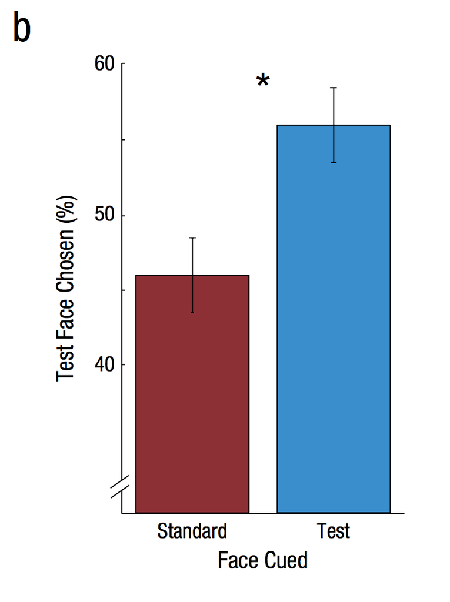

“The bar graph (b) shows the percentage of matched-face trials (Contrast Level 3) in which the test face was judged to have higher contrast than the standard face in each of the cue conditions. Error bars represent ±1 SEM (within subjects). *p<.05."

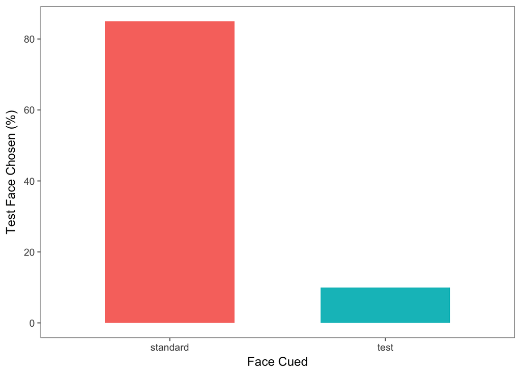

```r
d_t <- tbl[tbl$testContrast=="3",]
d_t <- d_t %>%
  group_by(workerid) %>%
  mutate(workerMean_3 = mean(pctTest)) %>%
  ungroup() %>%
  mutate(grandMean_3 = mean(workerMean)) %>%
  mutate(newPct3 = pctTest - workerMean_3 + grandMean_3)

bar <- d_t %>%
  group_by(cue) %>%
   # mean and within subject errors
  summarise(avePct=mean(pctTest), se=sd(newPct3)/sqrt(n()),
            ntrial=mean(n), aveTestChosen=mean(testChosen),
            sumTest=sum(testChosen), sumN=sum(n))

bar %>%
  ggplot(aes(x=cue,y=avePct,fill=cue)) +
  geom_bar(stat = "identity", position = "dodge",width = 0.6) +
  geom_linerange(aes(ymin=avePct-se, ymax=avePct+se)) +
  ggthemes::theme_few() +
  xlab("Face Cued") +
  ylab("Test Face Chosen (%)") +
   theme(legend.position="none")
```

```r
# conduct a paired t-test (test VS standard face, Contrast=3)
# d_test
# ttest<-t.test(pctTest ~ cue, d_t, paired=TRUE)
# ttest
# dz<-cohensD(pctTest ~ cue, data=d_t, method="paired")
# print(dz)
```

### Exploratory analyses

```r
#examine individual difference
# d_test %>%
#   ggplot(aes(x=cue,y=pctTest,group=workerid, color=workerid)) +
#   geom_line() +
#   geom_point(size=2)
```